# Thema 11 · Chi-kwadraat & Simpson

Deel 6 — Categorieën · *aantallen tellen*

# Van getallen naar categorieën

Tot nu toe verdiende elke meting een getal op een schaal: pienterheid, lengte, leeftijd. Maar veel waarnemingen zijn **categorisch**: bruin / grijs / zwart, geslaagd / gezakt, links / midden / rechts. Daar begin je niet met gemiddelden, maar met **tellen**. En daar past één toetsfamilie: de **chi-kwadraat**.

Twee smaken:

1. **Goodness-of-fit** — past mijn ene categorische variabele bij een verwachte verdeling? (Eén rij.)
2. **Onafhankelijkheid** — hangen twee categorische variabelen samen? (Een kruistabel.)

Beide draaien om hetzelfde recept: vergelijk **geobserveerd** met **verwacht** onder $H_0$, en tel de gestandaardiseerde afwijkingen op. Het is opnieuw **DATA = FIT + RESIDU**: wat zien we ($O$), wat verwacht het model ($E$), en hoeveel blijft er over ($O - E$)?

# Chi-kwadraat goodness-of-fit

**OpmerkingDe egels — drie pelskleuren**

Onder egels zien we drie pelskleuren: bruin, grijs en zwart. De biologen vermoeden dat ze in de natuur gelijk verdeeld zijn (1/3 elk). Wij vangen er 90 en zien: **40 bruin, 30 grijs, 20 zwart**. Klopt de gelijke verdeling, of niet?

Onder $H_0$ (gelijke verdeling) verwachten we $90/3 = 30$ egels per kleur. Bereken voor elke categorie het verschil en kwadrateer dat (we **kwadrateren** zodat plus- en min-afwijkingen elkaar niet wegvlakken — net als bij de blauwe vierkantjes van de variantie in thema 1), gedeeld door $E$:

| kleur | geobs. $O$ | verw. $E$ | $O - E$ | $\dfrac{O-E}{\sqrt{E}}$ | $\dfrac{(O-E)^2}{E}$ |
| --- | --- | --- | --- | --- | --- |
| bruin | 40 | 30 | +10 | **+1,83** | 3,33 |
| grijs | 30 | 30 | 0 | 0 | 0 |
| zwart | 20 | 30 | −10 | **−1,83** | 3,33 |
|  |  |  |  |  | **χ² = 6,67** |

Vrijheidsgraden: $df = k - 1 = 3 - 1 = 2$. Kritieke waarde $\chi^2_{.05, df=2} = 5{,}99$ (uit de tabel). Onze 6,67 is groter → **verwerp de nulhypothese**: de pelskleuren zijn níét gelijk verdeeld.

Maar $\chi^2$ zelf zegt alleen *dát* het patroon afwijkt — de **cellen** vertellen *waar*. Daarvoor lees je de **gestandaardiseerde residuen** $\dfrac{O-E}{\sqrt{E}}$ (de vierde kolom): bruin zit **+1,83** boven verwachting, zwart **−1,83** eronder, grijs precies goed. Een residu voorbij ongeveer ±2 is een opvallende cel. En kwadrateer je zo’n residu, dan krijg je exact die cel z’n **bijdrage aan $\chi^2$** ($1{,}83^2 \approx 3{,}33$) — samen weer 6,67. Zo zie je niet alleen of het afwijkt, maar welke kleur het verschil maakt.

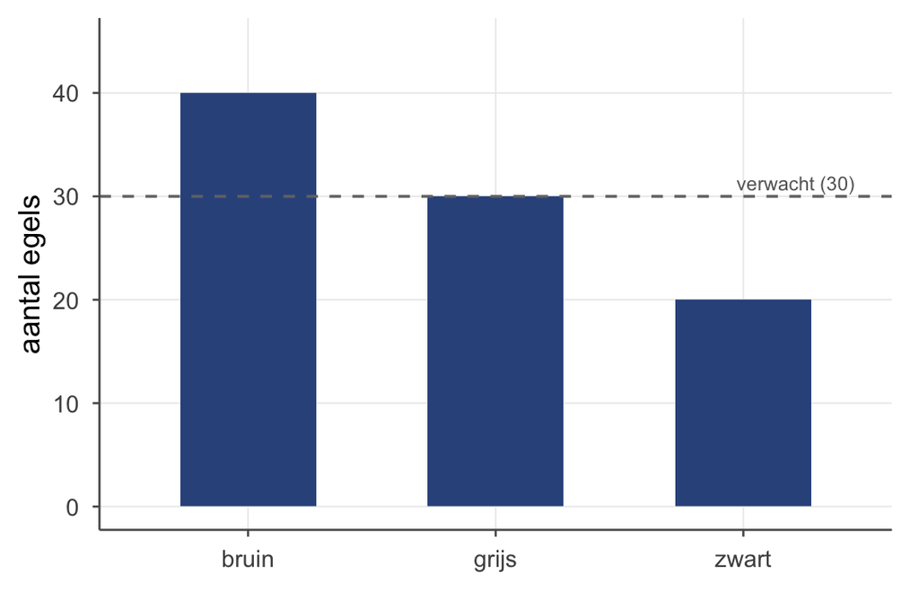

Figuur 1: Geobserveerd (blauw) vs verwacht onder gelijke verdeling (grijze stippellijn op 30). Bruin zit boven het verwachte, zwart eronder; samen levert dat een chi-kwadraat van 6,67.

# Chi-kwadraat onafhankelijkheid (kruistabel)

**OpmerkingStudenten — oefenmethode × tentamen**

We hebben 200 eerstejaars Pedagogiek, verdeeld over twee oefenmethoden (een **nieuwe** en een **oude**), en we turven de tentamen-uitslag (gehaald / niet). Vraag: hangt de methode samen met slagen?

|  | gehaald | niet gehaald | rij-totaal |
| --- | --- | --- | --- |
| nieuwe methode | 85 | 15 | 100 |
| oude methode | 65 | 35 | 100 |
| **kolom-totaal** | 150 | 50 | 200 |

Onder $H_0$ (onafhankelijkheid) berekenen we de verwachte waarde per cel als $E = \dfrac{\text{rij-totaal} \cdot \text{kolom-totaal}}{N}$:

- E(nieuw, gehaald) = $100 \cdot 150 / 200 = 75$
- E(nieuw, niet) = $100 \cdot 50 / 200 = 25$
- E(oud, gehaald) = $75$, E(oud, niet) = $25$

Vervolgens $\sum (O-E)^2/E$ over alle vier de cellen:

$$\chi^2 = \frac{(85-75)^2}{75} + \frac{(15-25)^2}{25} + \frac{(65-75)^2}{75} + \frac{(35-25)^2}{25}$$
$$= 1{,}33 + 4{,}00 + 1{,}33 + 4{,}00 = 10{,}67$$

Vrijheidsgraden voor een kruistabel: $df = (r-1)(k-1) = 1 \cdot 1 = 1$. Kritieke waarde $\chi^2_{.05, df=1} = 3{,}84$. Onze 10,67 is fors groter → **verwerp de nulhypothese**: de tentamen-uitslag hangt samen met de oefenmethode (in dit verzonnen voorbeeld haalt de nieuwe methode vaker).

Welke cel drijft dat? Weer de gestandaardiseerde residuen $\dfrac{O-E}{\sqrt{E}}$: de twee **niet gehaald**-cellen springen eruit ($\pm 2{,}0$: $\tfrac{15-25}{\sqrt{25}} = -2{,}0$ bij nieuw, $+2{,}0$ bij oud), terwijl de gehaald-cellen kleiner zijn ($\pm 1{,}15$). Daar — bij wie het *niet* haalde — wijkt de werkelijkheid het sterkst van onafhankelijkheid af.

Eén waarschuwing: $\chi^2$ wordt vanzelf groter bij een grotere steekproef. Een hoge $\chi^2$ betekent dus *significant*, niet automatisch *een sterk verband* — maten voor de **sterkte** (zoals Cramérs V) leer je later.

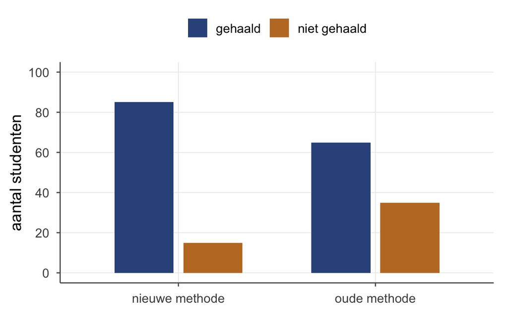

Figuur 2: Kruistabel als gegroepeerde staven: per oefenmethode het aantal gehaald (blauw) en niet gehaald (oranje). De ratio’s lopen duidelijk uit elkaar — vandaar een hoge chi-kwadraat.

**TipHet stappenplan voor een chi-kwadraat**

1. OV: hangen twee categorieën samen? (Of: past de verdeling bij wat verwacht?)
2. $H_0$: onafhankelijkheid (of: past bij verwachte verdeling). $H_1$: hangt samen (of: wijkt af).
3. Toetskeuze: chi-kwadraat (onafhankelijkheid of goodness-of-fit).
4. Onder $H_0$: bereken de verwachte aantallen per cel.
5. Toetsingsgrootheid: $\chi^2 = \sum (O-E)^2/E$.
6. df = $(r-1)(k-1)$ voor kruistabel; $k-1$ voor goodness-of-fit.
7. Vergelijk met $\chi^2_{\alpha, df}$ in de tabel.
8. Conclusie: *de samenhang tussen X en Y* — zeg wélk verband (richting en welke cellen beoordeel je uit de tabel en de residuen, niet uit $\chi^2$ zelf).

# De val van Simpson — een verband dat omkeert

Alles wat we sinds correlatie (thema 5) doen heeft één gevaar: een globaal verband kan subgroepen verbergen. Een kruistabel laat het *globale* plaatje zien. Maar soms verbergt dat plaatje een **omgekeerd** verband dat binnen subgroepen leeft. Dat is **Simpson’s paradox**, en je moet ’m kennen — anders trek je serieus de verkeerde conclusie.

**OpmerkingTwee opleidingen, één raar plaatje**

Een universiteit kijkt naar de slaagpercentages van jongens en meisjes bij twee opleidingen.

**Opleiding A (makkelijk):** jongens 480/800 = 60% geslaagd; meisjes 140/200 = **70%** geslaagd. → meisjes scoren beter.

**Opleiding B (moeilijk):** jongens 40/200 = 20% geslaagd; meisjes 200/800 = **25%** geslaagd. → meisjes scoren beter.

**Totaal:** jongens 520/1000 = **52%**; meisjes 340/1000 = **34%**. → jongens scoren beter ?!

Binnen elke opleiding doen meisjes het beter; maar in het totaal lijken jongens beter. Hoe kan dat? **Doordat de groepen zich anders verdelen over de opleidingen.** Veel meisjes deden de moeilijke opleiding (waar iederéén slechter scoort), en veel jongens de makkelijke. Dat trekt het meisjes-gemiddelde naar beneden en het jongens-gemiddelde omhoog.

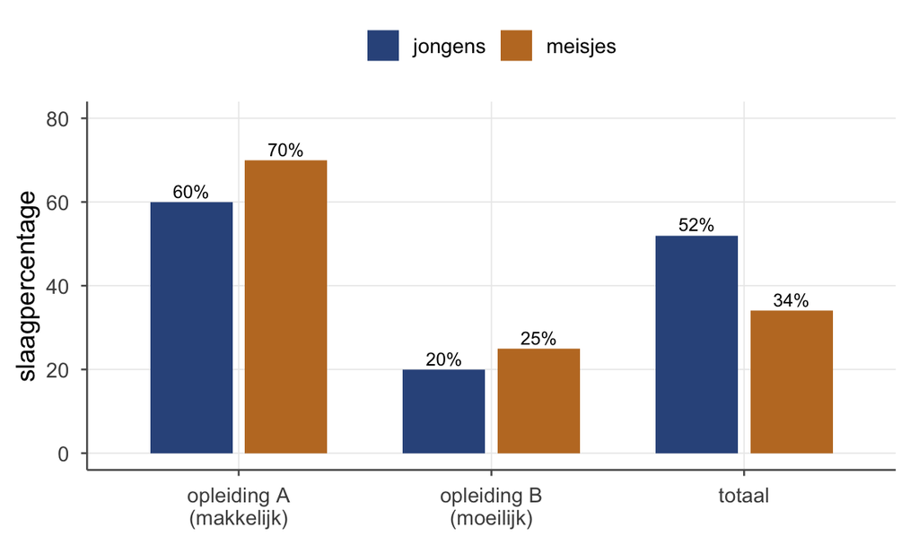

Figuur 3: Simpson-paradox visueel. Per opleiding (A makkelijk, B moeilijk) scoren meisjes hoger dan jongens. Maar in het totaal scoren jongens hoger — omdat ze relatief veel in de makkelijke opleiding zaten en meisjes in de moeilijke. De aggregatie verbergt de échte richting.

**BelangrijkLes uit Simpson**

Een **derde variabele** (hier: opleiding) die met beide andere samenhangt, kan een verband doen kantelen. *Aggregeer dus nooit zonder na te denken*: kijk altijd binnen relevante subgroepen. Dit is ook precies wat een covariaat doet in latere analyses — controleren voor zo’n meelopende variabele.

# Oefenen

**OpmerkingT11.1 — Chi-kwadraat met de hand**

Honderd egels worden in drie hokken gezet (links / midden / rechts). Onder $H_0$ verwachten we gelijke voorkeur. Telling: links 25, midden 50, rechts 25.

1. Bereken $\chi^2$.
2. Met $df = 2$ en $\chi^2_{.05} = 5{,}99$ — verwerpen?

**OpgeletAntwoord T11.1**

**(a)** $E = 100/3 \approx 33{,}33$ per hok. $(O-E)^2/E$: links $(25-33{,}33)^2/33{,}33 = 2{,}08$; midden $(50-33{,}33)^2/33{,}33 = 8{,}33$; rechts idem als links = 2,08. $\chi^2 = 2{,}08 + 8{,}33 + 2{,}08 = 12{,}5$.

**(b)** $12{,}5 > 5{,}99$ → verwerpen. De egels hebben een sterke voorkeur voor het middelste hok.

**OpmerkingT11.2 — Simpson herkennen**

Een schoolinspecteur bekijkt twee scholen op één-jaars-doorstroom. School X: 80%. School Y: 65%. School X lijkt beter. Maar binnen elke leerlingcategorie (laag / hoog vooropleidingsniveau) doet School Y het juist iets *beter*. Hoe kan dat?

**OpgeletAntwoord T11.2**

School X heeft waarschijnlijk veel meer leerlingen met een hoog vooropleidingsniveau (die sowieso vaker doorstromen, op elke school). Het aggregaatcijfer reflecteert dus vooral de samenstelling van de leerlingen, niet de kwaliteit van de school. Net als bij Simpson: een meelopende derde variabele (vooropleiding) verklaart het schijnverschil. Wie scholen eerlijk wil vergelijken, vergelijkt binnen vooropleidingsniveau — niet over de hoofden heen.

# Tot slot

Chi-kwadraat brengt de toets naar categorieën, met steeds dezelfde gedachte: vergelijk wat je ziet met wat je verwacht onder $H_0$, en tel de gestandaardiseerde afwijkingen op. En Simpson herinnert je dat aggregeren een vorm van vergeten is — de subgroepen zwijgen niet, je hoort ze alleen niet meer.

*Werkboek OZP 1 · Thema 11, versie 0.1 (handrekenen & theorie; SPSS later). Doorlopend voorbeeld: de egels (+ studenten).*

Terug naar boven